# Q1+q2

## Question 5: Audio Denoising with Spectral Processing

**Objective:** Develop deep learning models for audio denoising using spectral-domain processing (STFT/ISTFT) and neural network-based filtering.

**Implementation:** SpeechDenoisingDataset loads noisy/clean/noise audio triplets. Converts audio to spectrograms using STFT (n_fft=1024, hop_length=512) with librosa. Neural network processes spectrograms to predict clean signal. Reconstructs denoised audio via ISTFT. Evaluates using Signal-to-Noise Ratio (SNR) metrics and saves best model to handle overfitting.

```python
import torch
import torch.nn as nn
import torch.optim as optim
import librosa
import numpy as np
from torch.utils.data import Dataset, DataLoader
import os

class SpeechDenoisingDataset(Dataset):
    def __init__(self, noisy_folder, clean_folder, noise_folder, max_seq_length=None, pad_value=0):
        self.noisy_folder = noisy_folder
        self.clean_folder = clean_folder
        self.noise_folder = noise_folder
        self.max_seq_length = max_seq_length
        self.pad_value = pad_value
        self.file_paths = self._load_file_paths()

    def _load_file_paths(self):
        file_paths = []
        for i in range(1200):  # Files from 000 to 1199
            noisy_file = os.path.join(self.noisy_folder, f'trx{i:04d}.wav')
            clean_file = os.path.join(self.clean_folder, f'trs{i:04d}.wav')
            noise_file = os.path.join(self.noise_folder, f'trn{i:04d}.wav')
            file_paths.append((noisy_file, clean_file, noise_file))
        return file_paths

    def __len__(self):
        return len(self.file_paths)

    def __getitem__(self, idx):
        noisy_file, clean_file, noise_file = self.file_paths[idx]

        y_noisy, sr = librosa.load(noisy_file, sr=None)
        y_clean, _ = librosa.load(clean_file, sr=None)
        y_noise, _ = librosa.load(noise_file, sr=None)

        noisy_spec = librosa.stft(y_noisy,n_fft=1024, hop_length=512, win_length=1024)
        clean_spec = librosa.stft(y_clean,n_fft=1024, hop_length=512, win_length=1024)
        noise_spec = librosa.stft(y_noise,n_fft=1024, hop_length=512, win_length=1024)

        noisy_mag = np.abs(noisy_spec)
        clean_mag = np.abs(clean_spec)
        noise_mag = np.abs(noise_spec)

        ibm = (clean_mag > noise_mag).astype(np.float32)

        if self.max_seq_length:
            noisy_mag = self._pad_sequence(noisy_mag, self.max_seq_length)
            clean_mag = self._pad_sequence(clean_mag, self.max_seq_length)
            ibm = self._pad_sequence(ibm, self.max_seq_length)
        return torch.tensor(noisy_mag.T, dtype=torch.float32), torch.tensor(ibm.T, dtype=torch.float32)

    def _pad_sequence(self, sequence, max_length):

        #Pads a sequence to the max_length with the specified pad_value

        seq_len = sequence.shape[1]
        if seq_len < max_length:
            # Pad along the time axis (axis 1)
            padding = np.full((sequence.shape[0], max_length - seq_len), self.pad_value)
            return np.concatenate((sequence, padding), axis=1)
        else:
            return sequence[:, :max_length]
```

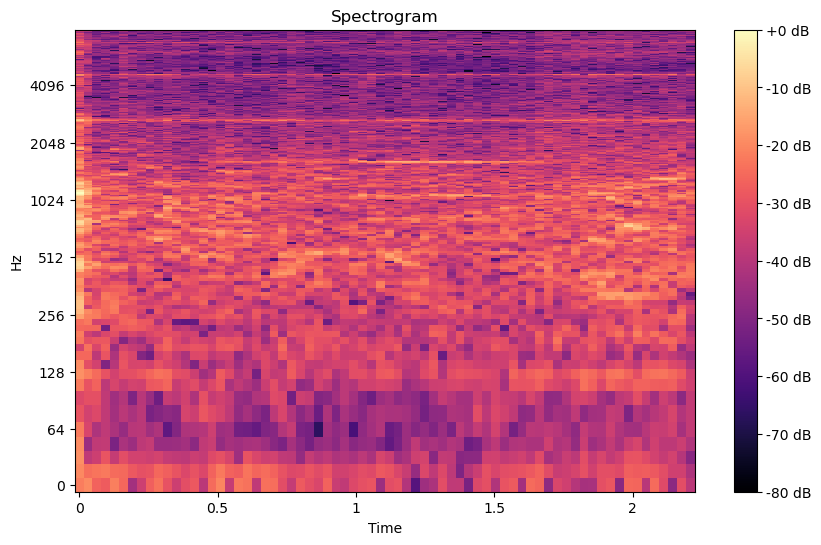

```
Spectrogram dimensions: (513, 70)
```

```python
#view the spectogram

import librosa.display
import matplotlib.pyplot as plt
file_path = './homework3/tr/trn0789.wav'
y, sr = librosa.load(file_path, sr=None)
D = librosa.stft(y, n_fft=1024, hop_length=512, win_length=1024)
S = np.abs(D)
plt.figure(figsize=(10, 6))
librosa.display.specshow(librosa.amplitude_to_db(S, ref=np.max), y_axis='log', x_axis='time', sr=sr)
plt.colorbar(format='%+2.0f dB')
plt.title('Spectrogram')
plt.show()
print("Spectrogram dimensions:", S.shape)
```

```python
import torch.nn as nn
import torch.optim as optim

class DenoisingGRU(nn.Module):
    def __init__(self, input_dim, hidden_dim, output_dim, num_layers, dropout):
        super(DenoisingGRU, self).__init__()
        self.gru = nn.GRU(input_dim, hidden_dim, num_layers,
                          batch_first=True,
                          dropout=dropout,
                          bidirectional=True)
        self.layer_norm = nn.LayerNorm(hidden_dim * 2)
        self.fc = nn.Linear(hidden_dim * 2, output_dim)
        self.fc_dropout = nn.Dropout(dropout)

    def forward(self, x):
        gru_out, _ = self.gru(x)
        gru_out = self.layer_norm(gru_out)
        gru_out = self.fc_dropout(gru_out)
        mask = self.fc(gru_out)
        return torch.sigmoid(mask)
```

```python
def compute_snr(noisy_signal, clean_signal, denoised_signal):
    noise = noisy_signal - denoised_signal
    signal_power = np.sum(clean_signal ** 2)
    noise_power = np.sum(noise ** 2)
    snr = 10 * np.log10(signal_power / noise_power)
    return snr
```

```python
class SpeechDenoisingValidationDataset(Dataset):
    def __init__(self, noisy_folder, clean_folder, noise_folder, max_seq_length=None, pad_value=0):
        self.noisy_folder = noisy_folder
        self.clean_folder = clean_folder
        self.noise_folder = noise_folder
        self.max_seq_length = max_seq_length
        self.pad_value = pad_value
        self.file_paths = self._load_file_paths()
    def _load_file_paths(self):
        file_paths = []
        for i in range(120):  # Files from 000 to 119 for validation
            noisy_file = os.path.join(self.noisy_folder, f'vn{i:04d}.wav')
            clean_file = os.path.join(self.clean_folder, f'vs{i:04d}.wav')
            noise_file = os.path.join(self.noise_folder, f'vx{i:04d}.wav')
            file_paths.append((noisy_file, clean_file, noise_file))
        return file_paths

    def __len__(self):
        return len(self.file_paths)

    def __getitem__(self, idx):
        noisy_file, clean_file, noise_file = self.file_paths[idx]
        y_noisy, sr = librosa.load(noisy_file, sr=None)
        y_clean, _ = librosa.load(clean_file, sr=None)
        y_noise, _ = librosa.load(noise_file, sr=None)
        noisy_spec = librosa.stft(y_noisy,n_fft=1024, hop_length=512, win_length=1024)
        clean_spec = librosa.stft(y_clean,n_fft=1024, hop_length=512, win_length=1024)
        noise_spec = librosa.stft(y_noise,n_fft=1024, hop_length=512, win_length=1024)
        noisy_mag = np.abs(noisy_spec)
        clean_mag = np.abs(clean_spec)
        noise_mag = np.abs(noise_spec)
        ibm = (clean_mag > noise_mag).astype(np.float32)
        if self.max_seq_length:
            noisy_mag = self._pad_sequence(noisy_mag, self.max_seq_length)
            clean_mag = self._pad_sequence(clean_mag, self.max_seq_length)
            ibm = self._pad_sequence(ibm, self.max_seq_length)
        return torch.tensor(noisy_mag.T, dtype=torch.float32), torch.tensor(ibm.T, dtype=torch.float32)

    def _pad_sequence(self, sequence, max_length):
        seq_len = sequence.shape[1]
        if seq_len < max_length:
            padding = np.full((sequence.shape[0], max_length - seq_len), self.pad_value)
            return np.concatenate((sequence, padding), axis=1)
        else:
            return sequence[:, :max_length]
```

```python
val_folder = '.\\homework3\\v\\'
noisy_folder_val = val_folder
clean_folder_val = val_folder
noise_folder_val = val_folder
validation_dataset = SpeechDenoisingValidationDataset(noisy_folder_val, clean_folder_val, noise_folder_val, max_seq_length=150)
validation_loader = DataLoader(validation_dataset, batch_size=64, shuffle=False)
```

```python
from torch.utils.data import DataLoader
from torch.optim.lr_scheduler import ReduceLROnPlateau
batch_size = 120  # Batch size for training
learning_rate = 0.001  # Learning rate for the optimizer
train_folder = '.\\homework3\\tr'
noisy_folder = train_folder
clean_folder = train_folder
noise_folder = train_folder
train_dataset = SpeechDenoisingDataset(noisy_folder, clean_folder, noise_folder, max_seq_length=150)
train_loader = DataLoader(train_dataset, batch_size=batch_size, shuffle=True)
```

```python
# Initialize model, loss function, and optimizer
model = DenoisingGRU(input_dim=513, hidden_dim=128, output_dim=513, num_layers=2, dropout=0.2)
loss_fn = nn.BCELoss()
optimizer = optim.Adam(model.parameters(), lr=learning_rate, weight_decay=1e-5)  # Add L2 regularization
scheduler = ReduceLROnPlateau(optimizer, mode='min', factor=0.1, patience=30)
best_val_loss = float('inf')
num_epochs = 20
```